# Final pakchoi diversity analyses

```r
#add in species arrows
spec.envfit <- envfit(plot2, env=counts_wide.Hellinger)
spec.data.envfit <- data.frame(r=spec.envfit$vectors$r, p=spec.envfit$vectors$pvals)
species.long2 <- species.long(plot2, spec.data=spec.data.envfit)
#species that explain 10% of variation
species.long3 <- species.long2[species.long2$r >= 0.1, ]
#species.long3
ordiArrowMul(spec.envfit) #close to 2
```

```
## [1] 2.863237
```

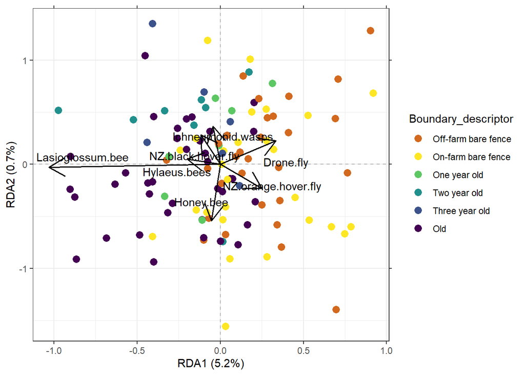

```r
plotgg2 <- ggplot() +
    geom_vline(xintercept = c(0), color = "grey70", linetype = 2) +
    geom_hline(yintercept = c(0), color = "grey70", linetype = 2) +
    xlab(axis.long2[1, "label"]) +
    ylab(axis.long2[2, "label"]) +
    scale_x_continuous(sec.axis = dup_axis(labels=NULL, name=NULL)) +
    scale_y_continuous(sec.axis = dup_axis(labels=NULL, name=NULL)) +
    geom_point(data=sites.long2,
               aes(x=axis1, y=axis2, colour=Boundary_descriptor),
               size=3) +
   scale_colour_manual(values=col_bound)+
    geom_segment(data=species.long3,
                 aes(x=0, y=0, xend=axis1*2, yend=axis2*4),
                 colour="black", size=0.7, arrow=arrow()) +
    geom_text_repel(data=species.long3,
                    aes(x=axis1*2, y=axis2*2, label=labels),
                    colour="black") +
    theme_bw()

plotgg2
```

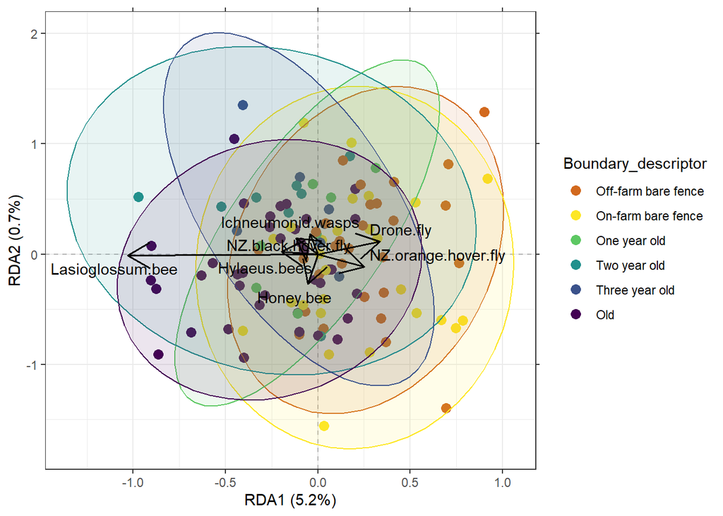

```r
#species and circles
plotgg2 <- ggplot() +
    geom_vline(xintercept = c(0), color = "grey70", linetype = 2) +
    geom_hline(yintercept = c(0), color = "grey70", linetype = 2) +
    xlab(axis.long2[1, "label"]) +
    ylab(axis.long2[2, "label"]) +
    scale_x_continuous(sec.axis = dup_axis(labels=NULL, name=NULL)) +
    scale_y_continuous(sec.axis = dup_axis(labels=NULL, name=NULL)) +
    geom_point(data=sites.long2,
               aes(x=axis1, y=axis2, colour=Boundary_descriptor),
               size=3) +
  stat_ellipse(data=sites.long2,
                      aes(x=axis1, y=axis2, colour=Boundary_descriptor, fill=Boundary_descriptor),
type='norm',level=0.95,geom='polygon',alpha=0.1,show.legend=F) +
    scale_colour_manual(values=col_bound)+
     scale_fill_manual(values=col_bound)+
    geom_segment(data=species.long3,
                 aes(x=0, y=0, xend=axis1*2, yend=axis2*2),
                 colour="black", size=0.7, arrow=arrow()) +
    geom_text_repel(data=species.long3,
                    aes(x=axis1*2, y=axis2*2, label=labels),
                    colour="black") +
    theme_bw()

plotgg2
```

```r
#alternative would be ddRDA or capscale on bray distance (PCoA) which might be better for us for differences between communities
cap <- capscale(counts_wide ~ Boundary_descriptorf + offset(log(`Flower count`)) + Condition(Season)+Condition(Farm_name)+Condition(month_split), data = meta_data_bior, distance = "bray")
#cap <- capscale(counts_wide.Hellinger ~ Boundary_descriptorf + offset(log(`Flower count`)) + Condition(Season)+Condition(Farm_name)+Condition(month_split), data = meta_data_bior, distance = "bray")

anova(cap, by = "terms")
```

```
## Permutation test for capscale under reduced model
## Terms added sequentially (first to last)
## Permutation: free
## Number of permutations: 999
##
## Model: capscale(formula = counts_wide ~ Boundary_descriptorf + offset(log(`Flower count`)) + Condition(Season) + Condition(Farm_name) + Condition(month_split), data = meta_data_bior, distance = "bray")
##                      Df SumOfSqs      F Pr(>F)
## Boundary_descriptorf  5   2.5253 2.3298  0.001 ***
## Residual             81  17.5593
## ---
## Signif. codes:  0 '***' 0.001 '**' 0.01 '*' 0.05 '.' 0.1 ' ' 1
```

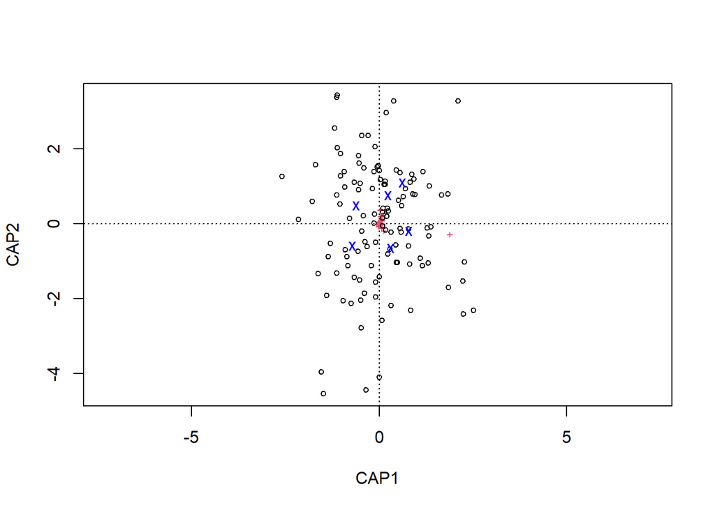

```r
plot(cap)
```

```r
site_scores <- scores(cap, display = "sites")
species_scores <- scores(cap, display = "species")
centroids <- scores(cap, display = "cn")


df_sites <- as.data.frame(site_scores)
df_sites$unique_sample <- rownames(df_sites)
capscale_df <- left_join(df_sites,meta_data)
```

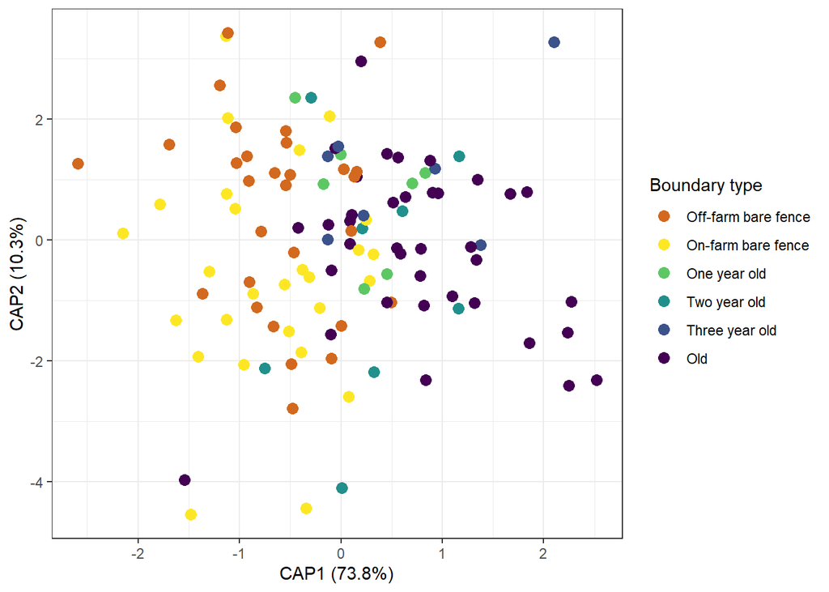

```r
capscale_df$Boundary_descriptor <- factor(capscale_df$Boundary_descriptor,levels=c('Off-farm bare fence','On-farm bare fence','One year old','Two year old','Three year old','Old'),ordered = T)

eig_vals <- cap$CCA$eig
prop_var <- eig_vals / sum(eig_vals)

xlab <- paste0("CAP1 (", round(prop_var[1] * 100, 1), "%)")
ylab <- paste0("CAP2 (", round(prop_var[2] * 100, 1), "%)")

#base plot
ggplot(capscale_df, aes(x = CAP1, y = CAP2, color = Boundary_descriptor)) +
  geom_point(size = 3) +
 scale_colour_manual(values=col_bound)+
  labs(x = xlab, y = ylab, color='Boundary type') +
  theme_bw()
```

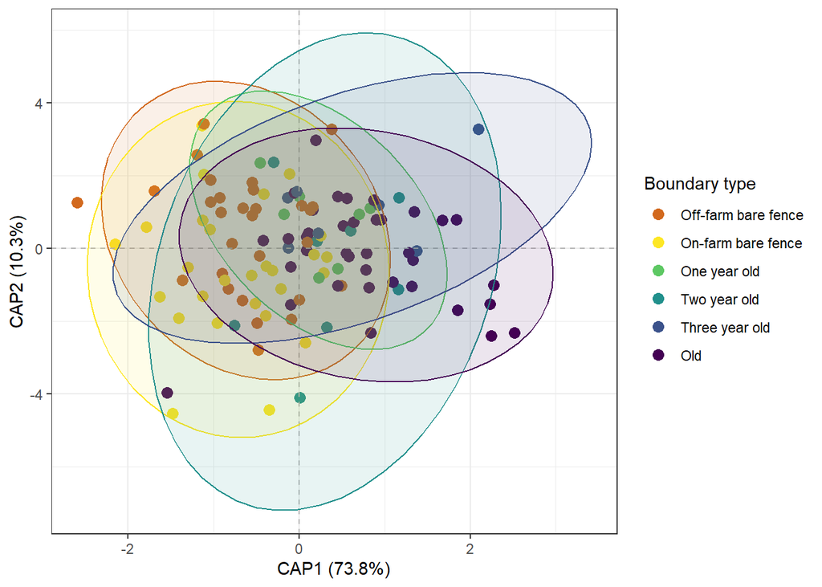

```r
#95% circles
ggplot() +
  geom_point(data=capscale_df, aes(x = CAP1, y = CAP2, color = Boundary_descriptor),size = 3) +
  scale_colour_manual(values=col_bound)+
  scale_fill_manual(values=col_bound)+
  labs(x = xlab, y = ylab, color='Boundary type') +
  geom_vline(xintercept = c(0), color = "grey70", linetype = 2) +
  geom_hline(yintercept = c(0), color = "grey70", linetype = 2) +
  stat_ellipse(data=capscale_df,
  aes(x = CAP1, y = CAP2, color = Boundary_descriptor,fill = Boundary_descriptor),
  type='norm',level=0.95,geom='polygon',alpha=0.1,show.legend=F)+
  theme_bw()
```

```r
#note species scores are calculated using euclidean distance in capscale which we assume correlates to brays
#so probably dump the species on in supplementary and say combined with standard RDA shows driven by lassio
# Calculate arrow length (distance from origin) to equate to species explaining most variation
#top species
sp_len <- sqrt(rowSums(species_scores^2))

# Rank species by length
head(sort(sp_len, decreasing = TRUE), 10)   # top 10 species for plot
```

```
##       Lasioglossum bee    NZ orange hover fly              Drone fly
##              1.9164478              0.3725165              0.3495208
##     NZ black hover fly              Honey bee      Striped flesh fly
##              0.2568091              0.2202592              0.2160044
## Buff-tailed bumble bee      Ichneumonid wasps          Other insects
##              0.1522280              0.1479941              0.1345391
##           Hylaeus bees
##              0.1337512
```

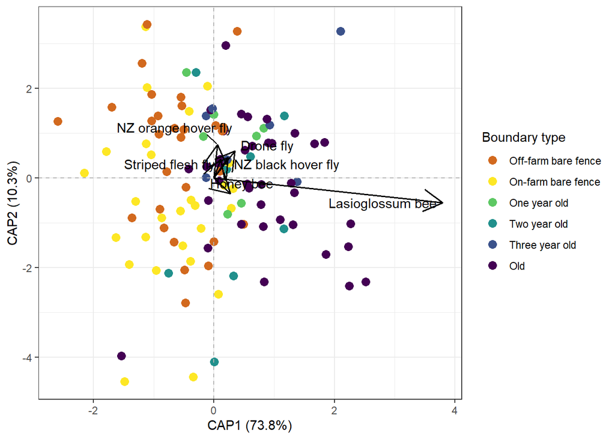

```r
keep <- names(sp_len[sp_len > quantile(sp_len, 0.9)])  # top 10% longest arrows
sp_filt <- species_scores[keep, ]

#species in plot
ggplot() +
  geom_point(data=capscale_df, aes(x = CAP1, y = CAP2, color = Boundary_descriptor),size = 3) +
  scale_colour_manual(values=col_bound)+
  labs(x = xlab, y = ylab, color='Boundary type') +
  geom_vline(xintercept = c(0), color = "grey70", linetype = 2) +
  geom_hline(yintercept = c(0), color = "grey70", linetype = 2) +
  geom_segment(data=sp_filt,
     aes(x=0, y=0, xend=CAP1*2, yend=CAP2*2),
     colour="black", size=0.7, arrow=arrow()) +
  geom_text_repel(data=sp_filt,
    aes(x=CAP1*2, y=CAP2*2, label=rownames(sp_filt)),
    colour="black") +
  theme_bw()
```

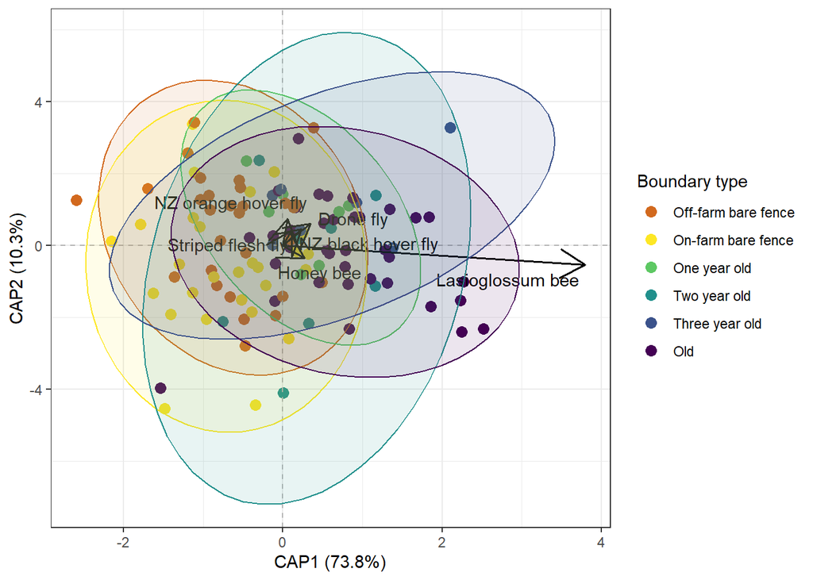

```r
#circles
ggplot() +
  geom_point(data=capscale_df, aes(x = CAP1, y = CAP2, color = Boundary_descriptor),size = 3) +
  scale_colour_manual(values=col_bound)+
  scale_fill_manual(values=col_bound)+
  labs(x = xlab, y = ylab, color='Boundary type') +
  geom_vline(xintercept = c(0), color = "grey70", linetype = 2) +
  geom_hline(yintercept = c(0), color = "grey70", linetype = 2) +
  geom_segment(data=sp_filt,
     aes(x=0, y=0, xend=CAP1*2, yend=CAP2*2),
     colour="black", size=0.7, arrow=arrow()) +
  geom_text_repel(data=sp_filt,
    aes(x=CAP1*2, y=CAP2*2, label=rownames(sp_filt)),
    colour="black") +
  stat_ellipse(data=capscale_df,
  aes(x = CAP1, y = CAP2, color = Boundary_descriptor,fill = Boundary_descriptor),
  type='norm',level=0.95,geom='polygon',alpha=0.1,show.legend=F)+
  theme_bw()
```

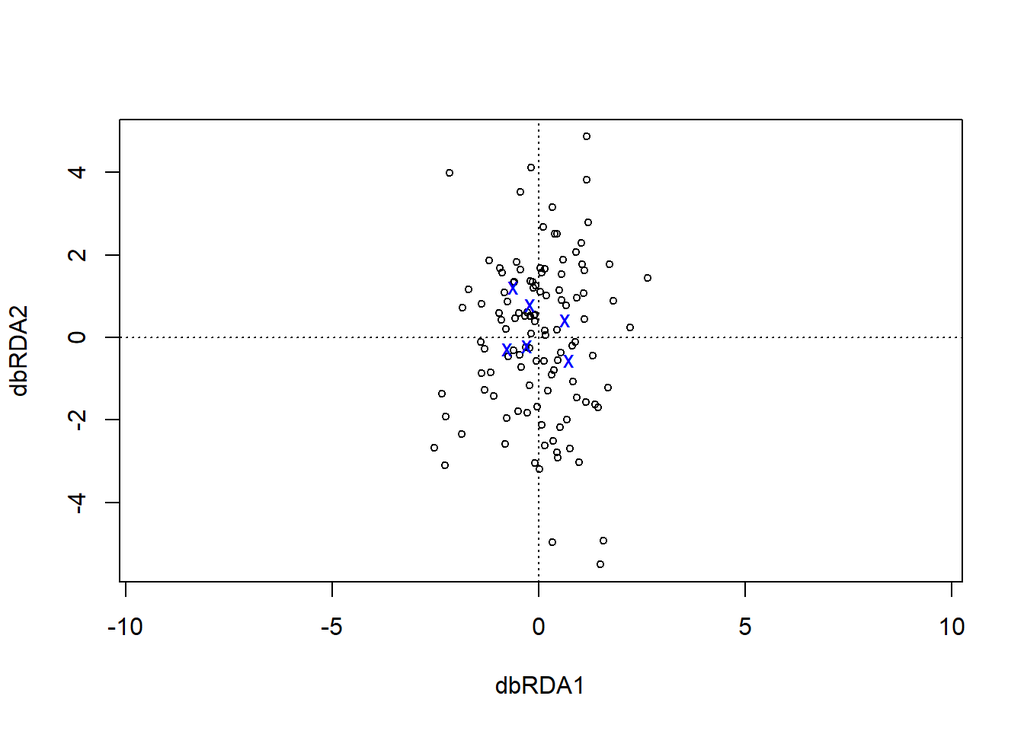

```r
#I think ddRDA is probably slightly better than capscale from what I've read but they do a similar thing

bound_dbrda <- dbrda(counts_wide ~ Boundary_descriptorf + offset(log(`Flower count`)) + Condition(Season)+Condition(Farm_name)+Condition(month_split), data = meta_data_bior, distance = "bray")
#bound_dbrda <- dbrda(counts_wide.Hellinger ~ Boundary_descriptorf + offset(log(`Flower count`)) + Condition(Season)+Condition(Farm_name)+Condition(month_split), data = meta_data_bior, distance = "bray")

bound_dbrda_summary<-summary(bound_dbrda)
plot(bound_dbrda)
```

```r
anova(bound_dbrda, by = "terms")
```

```
## Permutation test for dbrda under reduced model
## Terms added sequentially (first to last)
## Permutation: free
## Number of permutations: 999
##
## Model: dbrda(formula = counts_wide ~ Boundary_descriptorf + offset(log(`Flower count`)) + Condition(Season) + Condition(Farm_name) + Condition(month_split), data = meta_data_bior, distance = "bray")
##                      Df SumOfSqs      F Pr(>F)
## Boundary_descriptorf  5   2.3017 2.7948  0.001 ***
## Residual             81  13.3419
## ---
## Signif. codes:  0 '***' 0.001 '**' 0.01 '*' 0.05 '.' 0.1 ' ' 1
```

```r
site_scores <- scores(bound_dbrda, display = "sites")
centroids <- scores(bound_dbrda, display = "cn")


df_sites <- as.data.frame(site_scores)
df_sites$unique_sample <- rownames(df_sites)
bound_dbrda_df <- left_join(df_sites,meta_data)
```

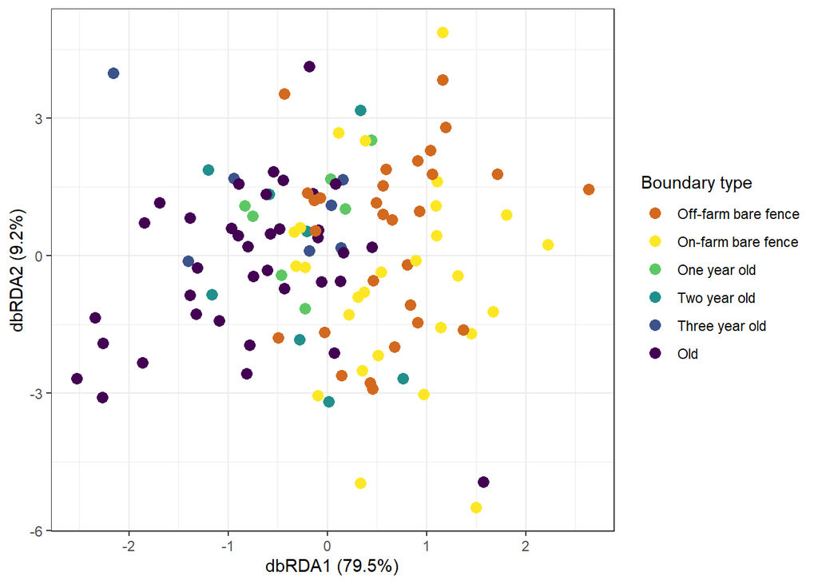

```r
bound_dbrda_df$Boundary_descriptor <- factor(capscale_df$Boundary_descriptor,levels=c('Off-farm bare fence','On-farm bare fence','One year old','Two year old','Three year old','Old'),ordered = T)

eig_vals <- bound_dbrda$CCA$eig
prop_var <- eig_vals / sum(eig_vals)

xlab <- paste0("dbRDA1 (", round(prop_var[1] * 100, 1), "%)")
ylab <- paste0("dbRDA2 (", round(prop_var[2] * 100, 1), "%)")

ggplot(bound_dbrda_df, aes(x = dbRDA1, y = dbRDA2, color = Boundary_descriptor)) +
  geom_point(size = 3) +
 scale_colour_manual(values=col_bound)+
  labs(x = xlab, y = ylab, color='Boundary type') +
  theme_bw()
```

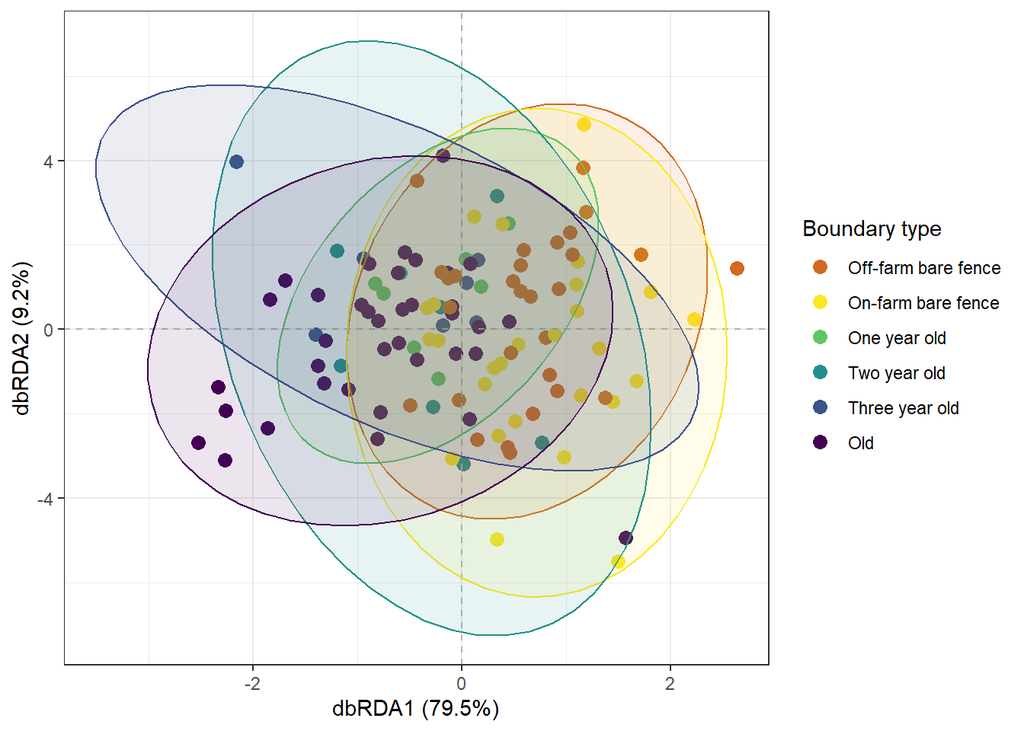

```r
#with circles
#95% circles
ggplot() +
  geom_point(data=bound_dbrda_df, aes(x = dbRDA1, y = dbRDA2, color = Boundary_descriptor),size = 3) +
  scale_colour_manual(values=col_bound)+
  scale_fill_manual(values=col_bound)+
  labs(x = xlab, y = ylab, color='Boundary type') +
  geom_vline(xintercept = c(0), color = "grey70", linetype = 2) +
  geom_hline(yintercept = c(0), color = "grey70", linetype = 2) +
  stat_ellipse(data=bound_dbrda_df, aes(x = dbRDA1, y = dbRDA2, color = Boundary_descriptor,fill=Boundary_descriptor),
  type='norm',level=0.95,geom='polygon',alpha=0.1,show.legend=F)+
  theme_bw()
```

```r
#add in species arrows
#rdRDA doesnt add species scores in automatically (due to them being calculated from the eucludian distance)
#using hellinger transformed here
sppscores(bound_dbrda)<-counts_wide.Hellinger

# Calculate arrow length (distance from origin) to equate to species explaining most variation
#top species
species_scores <- scores(bound_dbrda, display = "species")

sp_len <- sqrt(rowSums(species_scores^2))

# Rank species by length
head(sort(sp_len, decreasing = TRUE), 10)   # top 10 species for plot
```

```
##     Lasioglossum.bee            Drone.fly    Striped.flesh.fly
##            1.6437847            0.5741673            0.4609272
##  NZ.orange.hover.fly         Hylaeus.bees            Honey.bee
##            0.3638491            0.3320989            0.3165287
##   NZ.black.hover.fly    NZ.blue.hover.fly Bronze.cluster.flies
##            0.2744318            0.2134504            0.2083679
##    Ichneumonid.wasps
##            0.2000354
```

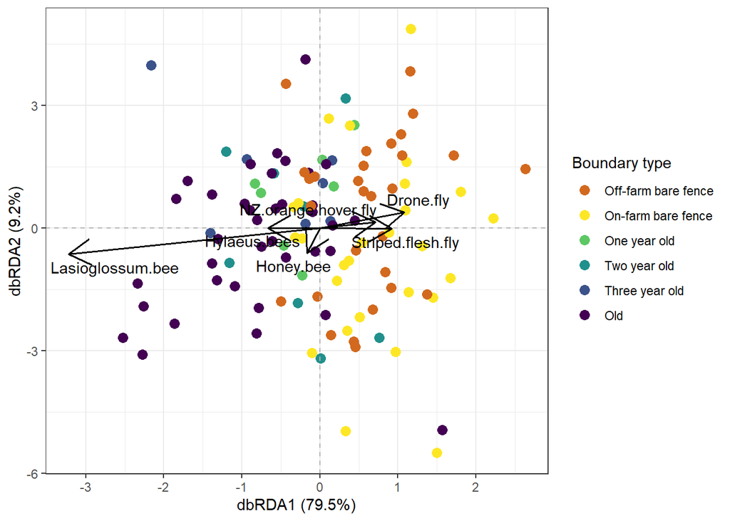

```r
keep <- names(sp_len[sp_len > quantile(sp_len, 0.9)])  # top 10% longest arrows
sp_filt <- species_scores[keep, ]

#species in plot
ggplot() +
  geom_point(data=bound_dbrda_df, aes(x = dbRDA1, y = dbRDA2, color = Boundary_descriptor),size = 3) +
  scale_colour_manual(values=col_bound)+
  labs(x = xlab, y = ylab, color='Boundary type') +
  geom_vline(xintercept = c(0), color = "grey70", linetype = 2) +
  geom_hline(yintercept = c(0), color = "grey70", linetype = 2) +
  geom_segment(data=sp_filt,
     aes(x=0, y=0, xend=dbRDA1*2, yend=dbRDA2*2),
     colour="black", size=0.7, arrow=arrow()) +
  geom_text_repel(data=sp_filt,
    aes(x=dbRDA1*2, y=dbRDA2*2, label=rownames(sp_filt)),
    colour="black") +
  theme_bw()
```

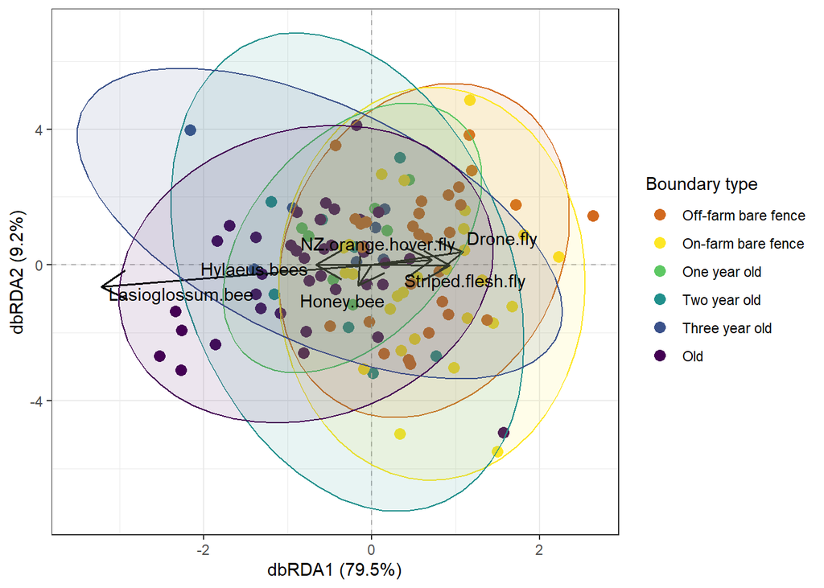

```r
#add in species arrows & eclipses
ggplot() +
  geom_point(data=bound_dbrda_df, aes(x = dbRDA1, y = dbRDA2, color = Boundary_descriptor),size = 3) +
  scale_colour_manual(values=col_bound)+
  scale_fill_manual(values=col_bound)+
  labs(x = xlab, y = ylab, color='Boundary type') +
  geom_vline(xintercept = c(0), color = "grey70", linetype = 2) +
  geom_hline(yintercept = c(0), color = "grey70", linetype = 2) +
  geom_segment(data=sp_filt,
     aes(x=0, y=0, xend=dbRDA1*2, yend=dbRDA2*2),
     colour="black", size=0.7, arrow=arrow()) +
  stat_ellipse(data=bound_dbrda_df, aes(x = dbRDA1, y = dbRDA2, color = Boundary_descriptor,fill=Boundary_descriptor),
  type='norm',level=0.95,geom='polygon',alpha=0.1,show.legend=F)+
  geom_text_repel(data=sp_filt,
    aes(x=dbRDA1*2, y=dbRDA2*2, label=rownames(sp_filt)),
    colour="black") +
  theme_bw()
```

```r
#given the issues with pairwise adonis tests we could test the mean separation on the ordination axes with emmeans (maybe?)
# Extract site scores from dbRDA
site_scores <- scores(bound_dbrda, display = "sites")
site_scores_df <- data.frame(site_scores, Boundary_descriptor = meta_data$Boundary_descriptor)

# Fit linear models per axis
lm1 <- lm(dbRDA1 ~ Boundary_descriptor, data = site_scores_df)
lm2 <- lm(dbRDA2 ~ Boundary_descriptor, data =site_scores_df)

# Pairwise comparisons
library(emmeans)
emmeans(lm1, pairwise ~ Boundary_descriptor, adjust = "tukey")
```

```
## $emmeans
##  Boundary_descriptor emmean    SE  df lower.CL upper.CL
##  Off-farm bare fence  0.623 0.140 109    0.345   0.9015
##  Old                 -0.784 0.124 109   -1.031  -0.5381
##  On-farm bare fence   0.714 0.146 109    0.426   1.0024
##  One year old        -0.233 0.286 109   -0.799   0.3334
##  Three year old      -0.623 0.286 109   -1.189  -0.0562
##  Two year old        -0.292 0.267 109   -0.822   0.2376
##
## Confidence level used: 0.95
##
## $contrasts
##  contrast                                     estimate    SE  df t.ratio
##  (Off-farm bare fence) - Old                    1.4077 0.188 109   7.507
##  (Off-farm bare fence) - (On-farm bare fence)  -0.0908 0.202 109  -0.449
##  (Off-farm bare fence) - One year old           0.8562 0.318 109   2.689
##  (Off-farm bare fence) - Three year old         1.2457 0.318 109   3.913
##  (Off-farm bare fence) - Two year old           0.9154 0.302 109   3.032
##  Old - (On-farm bare fence)                    -1.4985 0.191 109  -7.831
##  Old - One year old                            -0.5515 0.312 109  -1.770
##  Old - Three year old                          -0.1620 0.312 109  -0.520
##  Old - Two year old                            -0.4923 0.295 109  -1.670
##  (On-farm bare fence) - One year old            0.9469 0.321 109   2.953
##  (On-farm bare fence) - Three year old          1.3365 0.321 109   4.168
##  (On-farm bare fence) - Two year old            1.0062 0.304 109   3.306
##  One year old - Three year old                  0.3896 0.404 109   0.964
##  One year old - Two year old                    0.0592 0.391 109   0.151
##  Three year old - Two year old                 -0.3303 0.391 109  -0.844
##  p.value
##   <.0001
##   0.9976
##   0.0857
##   0.0022
##   0.0350
##   <.0001
##   0.4894
##   0.9953
##   0.5544
##   0.0435
##   0.0009
##   0.0158
##   0.9283
##   1.0000
##   0.9584
##
## P value adjustment: tukey method for comparing a family of 6 estimates
```

```r
emmeans(lm2, pairwise ~ Boundary_descriptor, adjust = "tukey")
```

```
## $emmeans
##  Boundary_descriptor emmean    SE  df lower.CL upper.CL
##  Off-farm bare fence  0.426 0.354 109   -0.275    1.127
##  Old                 -0.270 0.313 109   -0.890    0.351
##  On-farm bare fence  -0.547 0.367 109   -1.274    0.179
##  One year old         0.792 0.720 109   -0.634    2.219
##  Three year old       1.222 0.720 109   -0.204    2.649
##  Two year old        -0.211 0.673 109   -1.546    1.123
##
## Confidence level used: 0.95
##
## $contrasts
##  contrast                                     estimate    SE  df t.ratio
##  (Off-farm bare fence) - Old                    0.6952 0.472 109   1.472
##  (Off-farm bare fence) - (On-farm bare fence)   0.9728 0.509 109   1.910
##  (Off-farm bare fence) - One year old          -0.3668 0.802 109  -0.457
##  (Off-farm bare fence) - Three year old        -0.7969 0.802 109  -0.994
##  (Off-farm bare fence) - Two year old           0.6368 0.761 109   0.837
##  Old - (On-farm bare fence)                     0.2777 0.482 109   0.576
##  Old - One year old                            -1.0620 0.785 109  -1.353
##  Old - Three year old                          -1.4920 0.785 109  -1.901
##  Old - Two year old                            -0.0583 0.743 109  -0.079
##  (On-farm bare fence) - One year old           -1.3396 0.808 109  -1.658
##  (On-farm bare fence) - Three year old         -1.7697 0.808 109  -2.191
##  (On-farm bare fence) - Two year old           -0.3360 0.767 109  -0.438
##  One year old - Three year old                 -0.4301 1.020 109  -0.422
##  One year old - Two year old                    1.0036 0.986 109   1.018
##  Three year old - Two year old                  1.4337 0.986 109   1.454
##  p.value
##   0.6830
##   0.4018
##   0.9974
##   0.9191
##   0.9599
##   0.9924
##   0.7548
##   0.4074
##   1.0000
##   0.5621
##   0.2506
##   0.9979
##   0.9982
##   0.9110
##   0.6937
##
## P value adjustment: tukey method for comparing a family of 6 estimates
```

```r
#
```

## iNEXT

iNEXT (iNterpolation and EXTrapolation) is an R package, available in CRAN and Github, for rarefaction and extrapolation of species diversity (Hill numbers). It’s a useful package to use if you want to make any predictions about sampling size or diversity.

### Hill numbers

Hill numbers are a set of diversity indices used in ecology and biodiversity assessments to quantify the richness and evenness of species in a given community. These indices were developed by Michael Hill and are widely used to summarize various aspects of biodiversity. Hill numbers are particularly useful because they provide a way to focus on different facets of diversity, depending on the specific questions or goals of a study. For a thorough introduction to Hill numbers check out: Alberdi & Gilbert

There are several Hill numbers, but they all share a common formula that relies on an exponent, denoted as “q.” The choice of the exponent determines which aspect of diversity is emphasized:

- Richness (q = 0): Hill number with q = 0 is also known as the “species richness” or “taxonomic distinctness” index. It simply counts the number of unique species in a community without considering their abundances. This index is valuable when you want to emphasize the presence or absence of species but not their relative abundance.
- Exponential Shannon entropy (q = 1): This index corresponds to the Shannon-Wiener diversity index (commonly referred to as Shannon entropy) when q is set to 1. It considers both the richness and the evenness of species abundances. It is often used when you want to give equal importance to species richness and evenness.
- Inverse Simpson index (q = 2): The Inverse Simpson index corresponds to the Simpson diversity index when q is set to 2. This index emphasizes the dominance of the most abundant species in a community. It is often used when you want to give more weight to the presence of dominant species.
- Higher Hill numbers (q > 2): These Hill numbers give increasing weight to the most abundant species, placing more emphasis on the dominant species in the community. The larger the value of q, the more sensitive the index becomes to the presence of dominant species.

Hill numbers offer a flexible framework for assessing biodiversity because they allow you to choose the appropriate value of q based on the specific ecological question or management objective you are addressing. For example:

- If you want to measure the overall diversity of a community while considering both species richness and evenness, you might use q = 1.
- If you are concerned about the impact of a few highly dominant species in an ecosystem, you might use q = 2 or a higher value to focus on those dominant species.

#iNEXT package iNEXT is a neat package that can calculate Hill numbers, enabling us to investigate alpha diversity accumulation curves (similar to species accumulation curves). These graphs can help us determine if sufficient sampling was conducted at each site, based on the plateauing of the curves, similar to the rarefaction curves. But iNEXT.3D goes beyond rarefraction and extrapolates alpha diversity numbers beyond the number of samples collected (default is double sample number). Its written by Anne Chao and you can find her papers here: https://sites.google.com/view/chao-lab-website/home

### Running iNEXT

```r
#innext uses a weird list of lists, this is a annoying format to get into
#im using raw incident data as the input (thus it is made binary at one point in the code)

#generate a list of the unique sample locations
categories <- unique(data$Boundary_descriptor)
categories
```

```
## [1] "Off-farm bare fence" "One year old"        "Two year old"
## [4] "Three year old"      "Old"                 "On-farm bare fence"
```

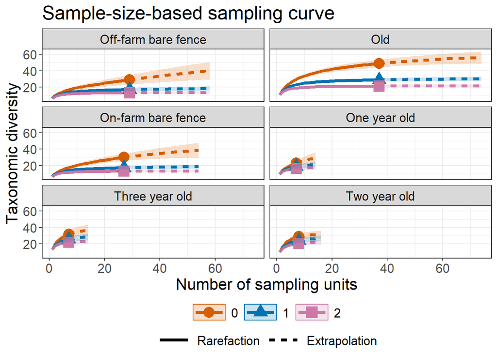

```r
#create empty list
split_list <- list()
#fill empty list with a presence absence OTU from each location

data<-data %>% mutate(unique_ob=paste(Boundary_descriptor,Farm_name,Season))

for (category in categories) {
  subset_data <- data %>% filter(Boundary_descriptor == category)
  test<-subset_data %>% ungroup() %>% dplyr::select(unique_ob,`New Inseck key name`,`Sum of Insects/100 flowers`)
  test   <- test %>%  spread(key = unique_ob, value = `Sum of Insects/100 flowers`)
  test<-test %>% remove_rownames %>% column_to_rownames(var="New Inseck key name")
  test<-test %>% mutate(across(everything(), ~ ifelse(. > 0, 1, 0)))
  split_list[[category]]<-as(test,'matrix')
}

matrix_list <- list(data = list())
for (category in categories) {
  otu_table <- as(split_list[[category]], "matrix")
  matrix_list[["data"]][[category]] <- otu_table
}

#here Im setting the endpoint as NULL which is double the input sample size (this is probably most robust)
out.raw <- iNEXT3D(data = matrix_list$data, diversity = 'TD', q = c(0, 1, 2), datatype = 'incidence_raw', nboot = 50,endpoint=NULL)

#there is various ways to look at these plots:
#within a sample
ggiNEXT3D(out.raw, type = 1, facet.var = 'Assemblage') + facet_wrap(~Assemblage, nrow = 3)
```

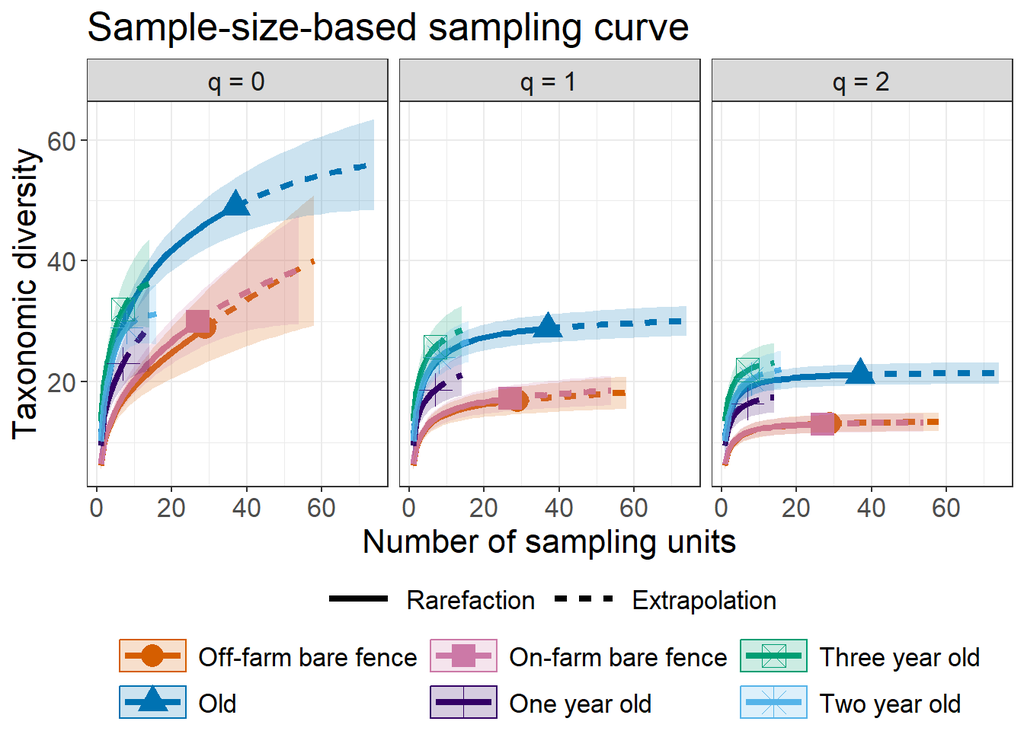

```r
#across samples
ggiNEXT3D(out.raw, type = 1, facet.var = "Order.q")
```

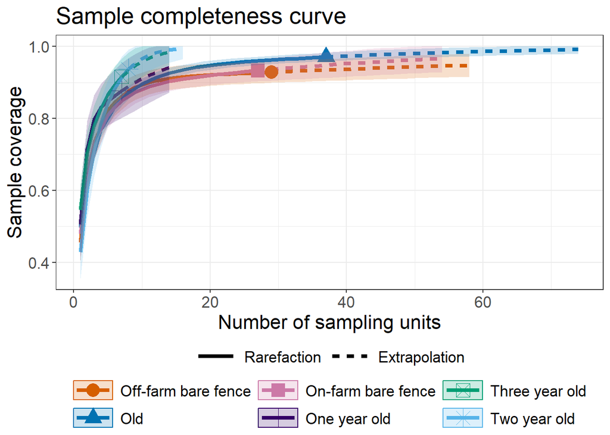

```r
#sample completeness
ggiNEXT3D(out.raw, type = 2, facet.var = "Order.q", color.var = "Assemblage")
```

```r
#using innext diversity estimates in a model
```

# Alternative plots for iNEXT

Here i have set the endpoint as 50 - I doubt this is robust for the 1,2,3 year plots but makes the plots even. ‘q1’ in particular looks squiffy at 50.

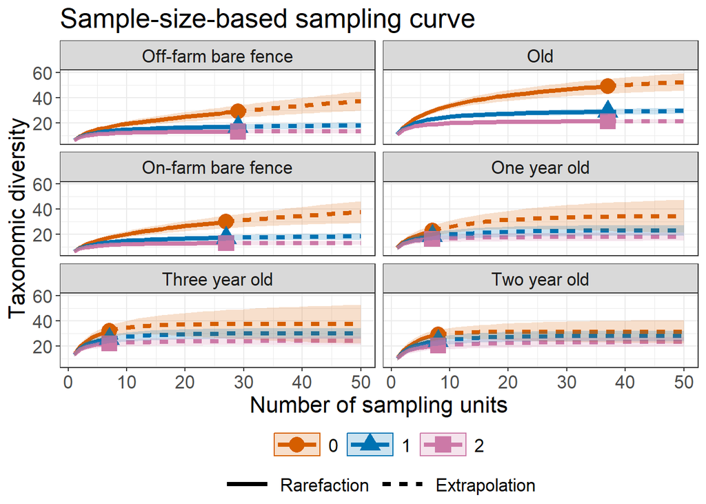

```r
out.raw <- iNEXT3D(data = matrix_list$data, diversity = 'TD', q = c(0, 1, 2), datatype = 'incidence_raw', nboot = 50,endpoint=50)

#there is various ways to look at these plots:
#within a sample
ggiNEXT3D(out.raw, type = 1, facet.var = 'Assemblage') + facet_wrap(~Assemblage, nrow = 3)
```

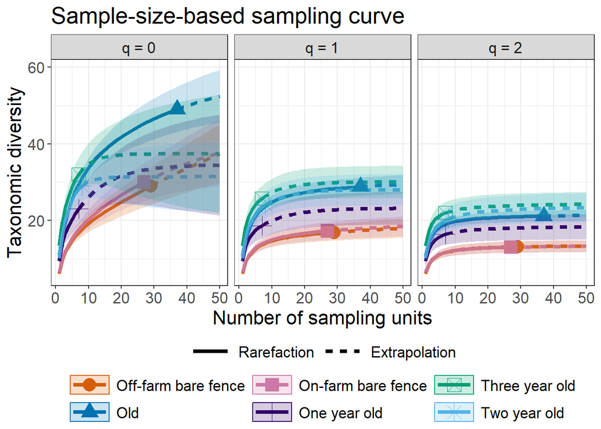

```r
#across samples
ggiNEXT3D(out.raw, type = 1, facet.var = "Order.q")
```

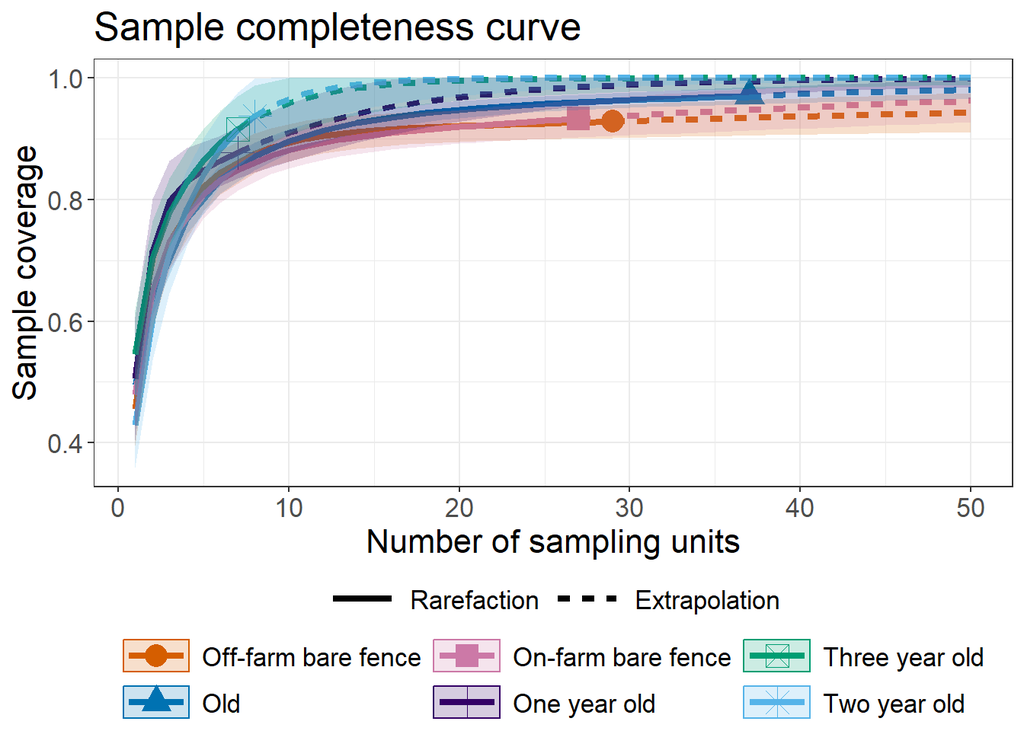

```r
#sample completeness
ggiNEXT3D(out.raw, type = 2, facet.var = "Order.q", color.var = "Assemblage")
```